# F4SC. Simple Exponential Smoothing

Author

Bertrand Haas

Published

October 30, 2025

# R environment setting

Required libraries:

```r
cran_repo <- "https://ftp.fau.de/cran"
list_Rpack2use <-
  c("rmarkdown",
    "conflicted",
    "devtools",
    "knitr",
    "quarto",
    "bookdown",
    #shiny,
    "DT",
    "Hmisc",
    "tidyverse",
    "magrittr",
    "lubridate",
    "hms",
    "glue",
    "skimr",
    "lobstr",
    "janitor",
    "zeallot",
    "stringi",
    "lemon",
    "crayon",
    "jsonlite",
    #"officer",
    "TSA",
    "tsibble",
    "fable",
    "feasts",
    "imputeTS",
    "readxl",
    "slider",
    "reticulate",
    "aws.s3",
    "paws",
    "RAthena",
    "botor",
    "RPostgres",
    "DBI",
    "RJDBC",
    "dbplyr",
    "arrow",
    "geosphere",
    "viridis")

list_installed_packages <- names(installed.packages()[,2])
for (Rpack in list_Rpack2use) {
  if (! Rpack %in% list_installed_packages) {
    print(paste("Installing", Rpack))
    install.packages(Rpack, repos = cran_repo, )
  } else {
    print(paste(Rpack, "already installed."))
  }
}
```

Loaded librairies:

```r
list_Rpack2load_not <-
  c("conflicted",
    "devtools",
    "paws",
    "RAthena",
    "botor",
    "arrow",
    "RPostgres",
    "DBI",
    "RJDBC",
    "dbplyr",
    "aws.s3",
    "arrow",
    "reticulate",
    "slider",
    "stringi",
    "geosphere",
    "blah")
list_Rpack2load <- setdiff(list_Rpack2use, list_Rpack2load_not)
list_Rpack2load
```

```
 [1] "rmarkdown" "knitr"     "quarto"    "bookdown"  "DT"        "Hmisc"
 [7] "tidyverse" "magrittr"  "lubridate" "hms"       "glue"      "skimr"
[13] "lobstr"    "janitor"   "zeallot"   "lemon"     "crayon"    "jsonlite"
[19] "TSA"       "tsibble"   "fable"     "feasts"    "imputeTS"  "readxl"
[25] "viridis"
```

```r
for (Rpack in list_Rpack2load) {
  library(Rpack, character.only = TRUE)
}

conflicted::conflicts_prefer(pillar::dim_desc)
conflicted::conflicts_prefer(magrittr::extract)
conflicted::conflicts_prefer(dplyr::filter)
conflicted::conflicts_prefer(jsonlite::flatten)
conflicted::conflicts_prefer(hms::hms)
conflicted::conflicts_prefer(dbplyr::ident)
conflicted::conflicts_prefer(lubridate::interval)
conflicted::conflicts_prefer(dplyr::lag)
conflicted::conflicts_prefer(readxl::read_xlsx)
conflicted::conflicts_prefer(magrittr::set_names)
conflicted::conflicts_prefer(dbplyr::sql)
conflicted::conflicts_prefer(Hmisc::src)
conflicted::conflicts_prefer(dplyr::summarize)
conflicted::conflicts_prefer(magrittr::is_in)
```

```r
#To pass if interactive
#rendering <- TRUE
#time_all <- proc.time()

source("./scripts_gal/misc_funs.R")

dir_data <- "./data/"

if (!dir.exists(dir_data)) {
  dir.create(dir_data)
}
```

# Simple Exponential Smoothing (SES)

Simple Exponential Smoothing (SES) is a forecasting method used for time series data that do not show any clear trend or seasonality. It assigns exponentially decreasing weights to past observations, meaning more recent observations have a stronger influence on the forecast than older ones.

## Mathematical Formulation

The updating equation is:

$$\hat{y}_{t+1|t} = \alpha y_t + (1 - \alpha)\hat{y}_{t|t-1}$$

where:

## Recursive Expansion

Expanding recursively gives:

$$\hat{y}_{t+1|t} = \alpha y_t + \alpha(1-\alpha)y_{t-1} + \alpha(1-\alpha)^2 y_{t-2} + \cdots$$

This shows that SES is a weighted average of all past observations, with weights that decay exponentially over time.

## Forecast Horizon

For all horizons ( h ):

$$\hat{y}_{t+h|t} = \hat{y}_{t+1|t}$$

This means that the forecast remains constant beyond the first step — SES assumes the future will continue at the same level.

## When to Use SES

Simple Exponential Smoothing is most appropriate when:

- The time series has no trend or seasonality.
- The data fluctuates randomly around a relatively stable mean.

## Model Selection

- Mean Squared Error (MSE)
- Mean Absolute Error (MAE)
- Akaike Information Criterion (AIC)

# Simple Exponential Smoothing through Kernel Smoothing

Simple Exponential Smoothing (SES) can be viewed as a special case of **kernel smoothing**, where the kernel function assigns exponentially decaying weights to past observations. This interpretation connects SES with nonparametric smoothing methods used in statistics.

## Kernel Smoothing Overview

$$\hat{y}_t = \sum_{j=1}^{t} K(t - j; \lambda) \, y_j$$

where:

The kernel weights are normalized so that:

$$\sum_{j=1}^{t} K(t - j; \lambda) = 1$$

## Exponential Kernel

In Simple Exponential Smoothing, the kernel function takes an **exponential form**:

$$K(t - j; \alpha) = \alpha (1 - \alpha)^{t - j}$$

Thus, the smoothed estimate becomes:

$$\hat{y}_t = \sum_{j=1}^{t} \alpha (1 - \alpha)^{t - j} y_j$$

which is equivalent to the recursive SES updating equation:

$$\hat{y}_{t+1|t} = \alpha y_t + (1 - \alpha)\hat{y}_{t|t-1}$$

## Interpretation

From the kernel-smoothing perspective:

## Connection to Other Kernels

While SES uses an exponential kernel, other kernel functions (such as Gaussian or uniform) can also be applied for smoothing in time series contexts. These alternatives lead to **symmetric kernel smoothers**, typically used for estimating trend components rather than forecasts.

In contrast, SES’s exponential kernel provides an **asymmetric, causal smoother**, suitable for real-time forecasting where only past information is available.

# Simple Exponential Smoothing thru kernel-smoothing

We have already seen some smoothing tools, like LOESS or GAM. LOESS works with a kernel, usually tricubic weights:
$$\begin{align*}
v_i &= (1 - (|d_i/d|)^3)^3 \\
w_i &= \frac{v_i}{\sum v_i}
\end{align*}$$

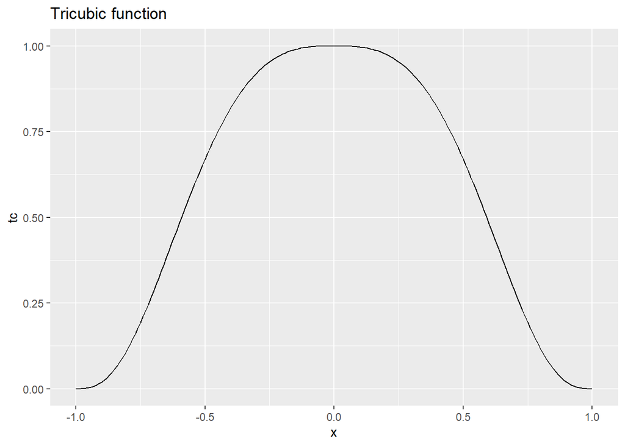

```r
tibble(x = seq(-1, 1, by = 0.01)) %>%
  mutate(tc = (1 - abs(x)^3)^3) %>%
  ggplot(aes(x, tc)) +
    geom_line() +
    ggtitle("Tricubic function")
```

These weights apply both on the right and on the left of the point under consideration (which corresponds to zero in the plot above), excepted at the boundary values. If we apply this kernel only to the last value of our Time Series, we get a value that can be interpreted as a forecast.

```r
lam <- 0.1
```

Instead of a tricubic kernel, we could also use a Normal, or an exponential kernel. Let’s try with an exponential kernel, that is, with weights proportional to $e^{-\lambda}$ for some parameter $\lambda$. We’ll use $\lambda = 0.1$ here.

We first load our usual synthetic data:

```r
fpath_ts2 <- glue("{dir_data}synthetic_TS_02.tsv")
df_ts2 <-
  read_tsv(fpath_ts2) %>%
  select(year, day, y_2) %>%
  mutate(day_noy = format(day, "0000-%m-%d") %>% as_date) %>% #date with no year
  relocate(day_noy, .after = day)
df_ts2
```

```
# A tibble: 1,008 × 4
    year day        day_noy      y_2
   <dbl> <date>     <date>     <dbl>
 1  2023 2023-01-01 0000-01-01  2.68
 2  2023 2023-01-02 0000-01-02  1.72
 3  2023 2023-01-03 0000-01-03  3.75
 4  2023 2023-01-04 0000-01-04  3.79
 5  2023 2023-01-05 0000-01-05  4.82
 6  2023 2023-01-06 0000-01-06  1.85
 7  2023 2023-01-07 0000-01-07  2.88
 8  2023 2023-01-08 0000-01-08  2.90
 9  2023 2023-01-09 0000-01-09  2.93
10  2023 2023-01-10 0000-01-10  1.95
# ℹ 998 more rows
```

And apply the exponential kernel:

```r
df_ts2$fcast_1 <- NA
for (i in 1:(nrow(df_ts2)-1)) {
  w_i <- exp(-lam * i:1)
  w_i <- w_i / sum(w_i)
  df_ts2$fcast_1[i+1] = sum(w_i * df_ts2$y_2[1:i])
}
```

Let’s check that for the first year (where we can see the first date), and plot the smoothed TS for each year.

```r
df_ts2  %>%
  filter(year == 2023)
```

```
# A tibble: 365 × 5
    year day        day_noy      y_2 fcast_1
   <dbl> <date>     <date>     <dbl>   <dbl>
 1  2023 2023-01-01 0000-01-01  2.68   NA
 2  2023 2023-01-02 0000-01-02  1.72    2.68
 3  2023 2023-01-03 0000-01-03  3.75    2.17
 4  2023 2023-01-04 0000-01-04  3.79    2.75
 5  2023 2023-01-05 0000-01-05  4.82    3.05
 6  2023 2023-01-06 0000-01-06  1.85    3.48
 7  2023 2023-01-07 0000-01-07  2.88    3.14
 8  2023 2023-01-08 0000-01-08  2.90    3.09
 9  2023 2023-01-09 0000-01-09  2.93    3.06
10  2023 2023-01-10 0000-01-10  1.95    3.04
# ℹ 355 more rows
```

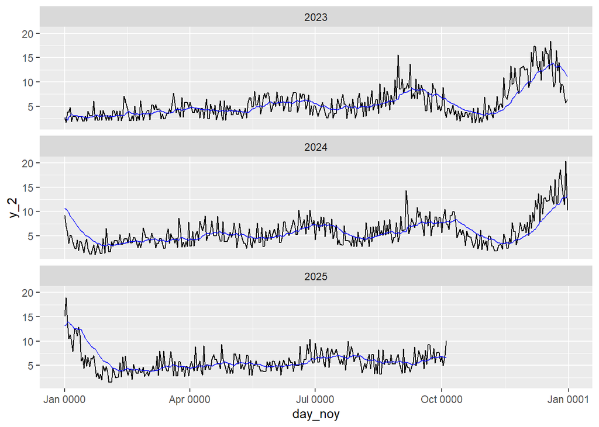

```r
df_ts2 %>%
  ggplot(aes(x = day_noy, y = y_2)) +
    geom_line() +
    geom_line(aes(y = fcast_1),
              color = "blue",
              alpha = 0.8) +
    facet_wrap(~year, ncol = 1)
```

**Important 1: To do at home**

Here we used $\lambda = 0.1$. Try the same code, but using $\lambda = 0.1$ and $\lambda = 0.9$. What do you observe?

It turns out that an exponential kernel can also be interpreted in a very simple (and computationally simple) way.

# Simple Exponential Smoothing thru recurrence

We’ll use the notations of [Data Science for Supply Chain Forecasting](https://www.oreilly.com/library/view/data-science-for/9783110671209/) for forecasts ($f$) and actual ($d$, for demand).

## Naive forecast

This follows the principle “What happens today is what happened yesterday”. In other words:
$$\begin{equation*}
f(t) = d(t-1)
\end{equation*}$$

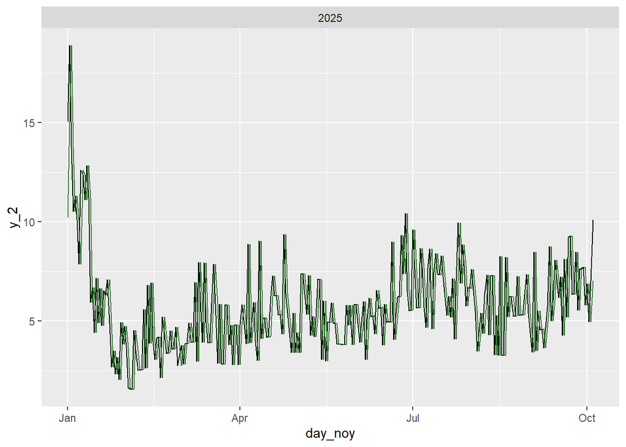

```r
df_ts2 %<>%
  mutate(fcast_naive = lag(y_2)) %>%
  relocate(fcast_naive, .before = fcast_1)

df_ts2 %>%
  filter(year == 2025) %>%
  ggplot(aes(x = day_noy, y = y_2)) +
    geom_line() +
    geom_line(aes(y = fcast_naive),
              color = "darkgreen",
              alpha = 0.8) +
    facet_wrap(~year, ncol = 1)
```

We clearly see the 1-day offset here.